# Paired and Independent t-test

27 sep 2016

## Inhoud

## Paired-samples t-test

Paired 2 samples

## Paired-samples t-test

In the Paired samples t-test the deviation (\(D\)) for each pair is calculated and the mean of these deviations (\(\bar{D}\)) is tested against the null hypothesis where \(\mu = 0\).

## Data example

We are going to use the IQ estimates we collected last week. You had to gues the IQ of the one sitting next to you and your own IQ.

Let's take a look at the data.

## IQ estimates

|  | Timestamp | IQ.van.je.buur | Eigen.IQ |
| --- | --- | --- | --- |
| 1 | 19/09/2013 21:19:26 | 130 | 124 |
| 2 | 19/09/2013 21:24:25 | 120 | 100 |
| 3 | 19/09/2013 21:24:41 | 120 | 156 |
| 4 | 20/09/2013 11:05:34 | 100 | 145 |
| 5 | 20/09/2013 11:05:52 | 100 | 145 |
| 6 | 20/09/2013 11:05:56 | 125 | 116 |
| 7 | 20/09/2013 11:06:02 | 134 | 129 |
| 8 | 20/09/2013 11:06:03 | 120 | 120 |
| 9 | 20/09/2013 11:06:04 | 128 | 125 |
| 10 | 20/09/2013 11:06:07 | 130 | 125 |

[output cut: 290 more lines]

## Calculate \(D\)

```r
D = IQ.van.je.buur - Eigen.IQ
```

|  | Timestamp | IQ.van.je.buur | Eigen.IQ | D |
| --- | --- | --- | --- | --- |
| 1 | 19/09/2013 21:19:26 | 130 | 124 | 6 |
| 2 | 19/09/2013 21:24:25 | 120 | 100 | 20 |
| 3 | 19/09/2013 21:24:41 | 120 | 156 | -36 |
| 4 | 20/09/2013 11:05:34 | 100 | 145 | -45 |
| 5 | 20/09/2013 11:05:52 | 100 | 145 | -45 |
| 6 | 20/09/2013 11:05:56 | 125 | 116 | 9 |
| 7 | 20/09/2013 11:06:02 | 134 | 129 | 5 |
| 8 | 20/09/2013 11:06:03 | 120 | 120 | 0 |
| 9 | 20/09/2013 11:06:04 | 128 | 125 | 3 |
| 10 | 20/09/2013 11:06:07 | 130 | 125 | 5 |

[output cut: 290 more lines]

## Calculate \(\bar{D}\)

```r
D      = na.omit(D) # get rid of all missing values
D.mean = mean(D)
D.mean
```

```
## [1] 0.3434343
```

And we also need n.

```r
n = length(D)
n
```

```
## [1] 297
```

## Calculate t-value

\[t_{n-1} = \frac{\bar{D} - \mu}{ {SE}_D }\]

```r
mu = 0                # Define mu

D.sd = sd(D)          # Calculate standard deviation
D.se = D.sd / sqrt(n) # Calculate standard error

df   = n - 1          # Calculate degrees of freedom

# Calculate t
t = ( D.mean - mu ) / D.se
t
```

```
## [1] 0.3371479
```

## Test for significance

Two tailed

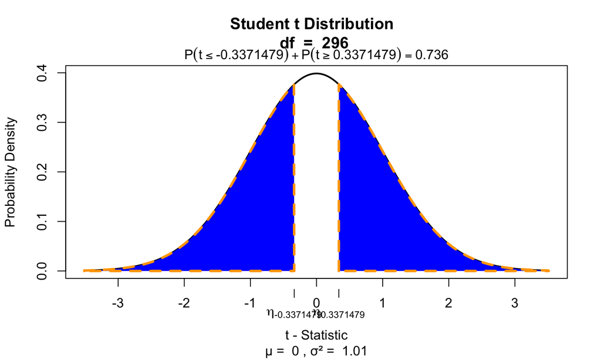

```r
if(!"visualize" %in% installed.packages()) { install.packages("visualize") }
library("visualize")

visualize.t(c(-t,t), df, section="tails")
```

## Effect-size

\[r = \sqrt{\frac{t^2}{t^2 + \text{df}}}\]

```r
r = sqrt(t^2/(t^2 + df))

r
```

```
## [1] 0.01959256
```

## Confidence interval

To display correct conficance intervals in SPSS we need to correct the original scores for whithin subject variation.

```
DATASET ACTIVATE DataSet1.
COMPUTE whithinmean=MEAN(IQ.van.je.buur,Eigen.IQ).
EXECUTE.

AGGREGATE
  /OUTFILE=* MODE=ADDVARIABLES
  /BREAK=
  /whithinmean_mean=MEAN(whithinmean).

COMPUTE adjustment=whithinmean_mean - whithinmean.
EXECUTE.

COMPUTE IQ.van.je.buur.adj = IQ.van.je.buur + adjustment.
COMPUTE Eigen.IQ           = Eigen.IQ       + adjustment.
EXECUTE.
```

## Independent-samples t-test

Compare 2 independent samples

## Independent-samples t-test

In the independent-samples t-test the mean of both independent samples is calculated and the difference of these \((\bar{X}_1 - \bar{X}_2)\) means is tested against the null hypothesis where \(\mu = 0\).

## Example

We are going to use the IQ estimates we collected last week again. You had to gues the IQ of the one sitting next to you and your own IQ. But we are going to add gender to the data set. We did not register this so we are going to simulate some genders.

```r
gender = sample(c("male", "female"), length(IQ.van.je.buur), replace = TRUE)
```

## The data

|  | Timestamp | IQ.van.je.buur | Eigen.IQ | gender |
| --- | --- | --- | --- | --- |
| 1 | 19/09/2013 21:19:26 | 130 | 124 | female |
| 2 | 19/09/2013 21:24:25 | 120 | 100 | male |
| 3 | 19/09/2013 21:24:41 | 120 | 156 | female |
| 4 | 20/09/2013 11:05:34 | 100 | 145 | male |
| 5 | 20/09/2013 11:05:52 | 100 | 145 | female |
| 6 | 20/09/2013 11:05:56 | 125 | 116 | male |
| 7 | 20/09/2013 11:06:02 | 134 | 129 | male |
| 8 | 20/09/2013 11:06:03 | 120 | 120 | female |
| 9 | 20/09/2013 11:06:04 | 128 | 125 | male |
| 10 | 20/09/2013 11:06:07 | 130 | 125 | male |

[output cut: 290 more lines]

## Calculate means

```r
Eigen.IQ.male   = subset(data, gender == "male",   select = Eigen.IQ)$Eigen.IQ
Eigen.IQ.female = subset(data, gender == "female", select = Eigen.IQ)$Eigen.IQ

Eigen.IQ.male.mean   = mean(Eigen.IQ.male,   na.rm = T)
Eigen.IQ.female.mean = mean(Eigen.IQ.female, na.rm = T)

Eigen.IQ.male.mean
```

```
## [1] 119.7122
```

```r
Eigen.IQ.female.mean
```

```
## [1] 121.4277
```

## Calculate variance

```r
Eigen.IQ.male.var   = var(Eigen.IQ.male,   na.rm = T)
Eigen.IQ.female.var = var(Eigen.IQ.female, na.rm = T)
Eigen.IQ.male.var
```

```
## [1] 212.1485
```

```r
Eigen.IQ.female.var
```

```
## [1] 95.3729
```

```r
Eigen.IQ.male.n   = length(Eigen.IQ.male)   - 1
Eigen.IQ.female.n = length(Eigen.IQ.female) - 1
Eigen.IQ.male.n
```

```
## [1] 139
```

```r
Eigen.IQ.female.n
```

```
## [1] 159
```

## Calculate t-value

\[t_{n_1 + n_2 -2} = \frac{(\bar{X}_1 - \bar{X}_2) - \mu}{{SE}_p}\]

Where \({SE}_p\) is the pooled standard error.

\[{SE}_p = \sqrt{\frac{S^2_p}{n_1}+\frac{S^2_p}{n_2}}\]

And \(S^2_p\) is the pooled variance.

\[S^2_p = \frac{(n_1-1)s^2_1+(n_2-1)s^2_2}{n_1+n_2-2}\]

Where \(s^2\) is the variance and \(n\) the sample size.

## Calculate pooled variance

\[S^2_p = \frac{(n_1-1)s^2_1+(n_2-1)s^2_2}{n_1+n_2-2}\]

```r
df = Eigen.IQ.male.n + Eigen.IQ.female.n - 2

s2.p = ( (Eigen.IQ.male.n-1)*Eigen.IQ.male.var + (Eigen.IQ.female.n-1)*Eigen.IQ.female.var ) / df

df
```

```
## [1] 296
```

```r
s2.p
```

```
## [1] 149.8156
```

## Calculate pooled SE

\[{SE}_p = \sqrt{\frac{S^2_p}{n_1}+\frac{S^2_p}{n_2}}\]

```r
se.p    = sqrt( ((s2.p/Eigen.IQ.male.n) + (s2.p/Eigen.IQ.female.n)) )
se.p
```

```
## [1] 1.421283
```

## Calculate t-value

\[t_{n_1 + n_2 -2} = \frac{(\bar{X}_1 - \bar{X}_2) - \mu}{{SE}_p}\]

```r
t = ( Eigen.IQ.male.mean - Eigen.IQ.female.mean ) / se.p

t
```

```
## [1] -1.206968
```

## Test for significance

Two tailed

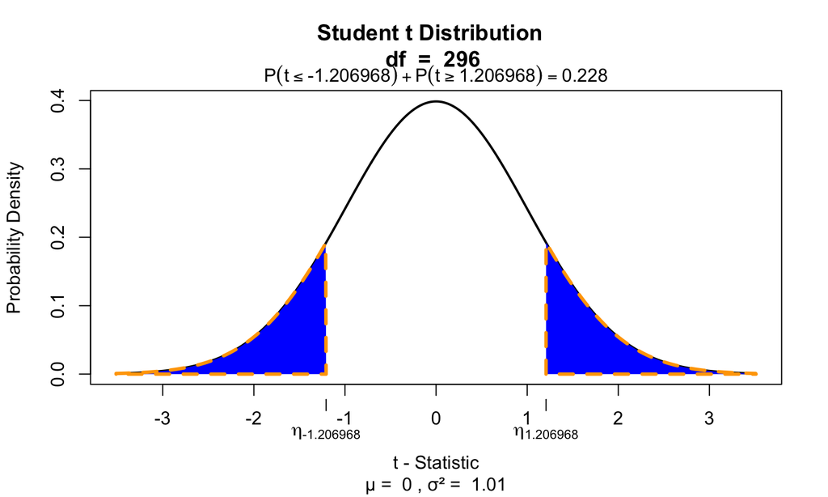

```r
if(!"visualize" %in% installed.packages()) { install.packages("visualize") }
library("visualize")

visualize.t(c(-t,t), df, section="tails")
```

## Effect-size

\[r = \sqrt{\frac{t^2}{t^2 + \text{df}}}\]

```r
r = sqrt(t^2/(t^2 + df))

r
```

```
## [1] 0.06998157
```

## END

[@shklinkenberg](https://twitter.com/shklinkenberg)